# Storm Data Analysis - Harmful Events and Economic Consequences

Vijay Ramanujam

September 24, 2017

## Synopsis

Storms and other severe weather events can cause both public health and economic problems for communities and municipalities. Many severe events can result in fatalities, injuries, and property damage, and preventing such outcomes to the extent possible is a key concern.

This project involves exploring the U.S. National Oceanic and Atmospheric Administration’s (NOAA) storm database. This database tracks characteristics of major storms and weather events in the United States, including when and where they occur, as well as estimates of any fatalities, injuries, and property damage.

The analysis answers 2 key questions.

1. Across the United States, which types of events are most harmful with respect to population health?
2. Across the United States, which types of events have the greatest economic consequences?

## Data Processing

#### 1. Define variables used

```r
# URL & filenames
sURL <- "https://d396qusza40orc.cloudfront.net/repdata%2Fdata%2FStormData.csv.bz2"
sZipFile <- "StormData.csv.bz2"
sCSVFile <- "StormData.csv"

# UOMs
K <- 10^3
M <- 10^6
B <- 10^9
```

#### 2. Download the compressed file, if not downloaded already.

```r
if(!file.exists(sZipFile))
{
    download.file(sURL, sZipFile, mode = "wb")
}
```

#### 3. Uncompress .csv, if not done already

```r
if (file.exists(sCSVFile) == FALSE)
{
    library(R.utils)
    bunzip2(sZipFile, sCSVFile)
}
```

#### 4. Read csv file and load data

```r
data <- read.csv(sCSVFile, header = TRUE)
```

#### 5. Filter the columns necessary for this analysis. i.e. “EVTYPE”, “FATALITIES”, “INJURIES”, “PROPDMG”, “PROPDMGEXP”, “CROPDMG”, and “CROPDMGEXP”

```r
tidy <- data[, c("EVTYPE","FATALITIES","INJURIES","PROPDMG","PROPDMGEXP","CROPDMG","CROPDMGEXP")]
```

#### 6. Transform property damages to $

```r
tidy$PropertyDamages <- 0
tidy[tidy$PROPDMGEXP=="K",]$PropertyDamages = tidy[tidy$PROPDMGEXP=="K",]$PROPDMG * K
tidy[tidy$PROPDMGEXP=="M",]$PropertyDamages = tidy[tidy$PROPDMGEXP=="M",]$PROPDMG * M
tidy[tidy$PROPDMGEXP=="B",]$PropertyDamages = tidy[tidy$PROPDMGEXP=="B",]$PROPDMG * B
```

#### 7. Transform crop damages to $

```r
tidy$CropDamages <- 0
tidy[tidy$CROPDMGEXP=="K",]$CropDamages = tidy[tidy$CROPDMGEXP=="K",]$CROPDMG * K
tidy[tidy$CROPDMGEXP=="M",]$CropDamages = tidy[tidy$CROPDMGEXP=="M",]$CROPDMG * M
tidy[tidy$CROPDMGEXP=="B",]$CropDamages = tidy[tidy$CROPDMGEXP=="B",]$CROPDMG * B
```

#### 8. Remove rows with no fatalities/injuries/damages

```r
tidy<-tidy[tidy$FATALITIES+tidy$INJURIES+tidy$PropertyDamages+tidy$CropDamages>0,c("EVTYPE","FATALITIES","INJURIES","PropertyDamages","CropDamages")]
tidy$EVTYPE <- toupper(tidy$EVTYPE)
```

#### 9. Convert damages into billions

```r
tidy$PropertyDamages <- tidy$PropertyDamages/B
tidy$CropDamages <- tidy$CropDamages/B
```

#### 10. Get summary data by event for plotting

```r
tidy$EVTYPE <- toupper(tidy$EVTYPE)
plotdata <- aggregate(cbind(FATALITIES, INJURIES, PropertyDamages, CropDamages)~EVTYPE, data=tidy, sum)
```

## Results

**Top 10 events across the United States that are most harmful with respect to population health**

**a) Fatalities**

```r
fatalities <- aggregate(FATALITIES ~ EVTYPE, data=plotdata, sum)
fatalities <- fatalities[order(-fatalities$FATALITIES), ][1:10, ]
fatalities$EVTYPE <- factor(fatalities$EVTYPE, levels = fatalities$EVTYPE)
fatalities
```

```
##             EVTYPE FATALITIES
## 366        TORNADO       5633
## 53  EXCESSIVE HEAT       1903
## 64     FLASH FLOOD        978
## 130           HEAT        937
## 229      LIGHTNING        816
## 381      TSTM WIND        504
## 76           FLOOD        470
## 272    RIP CURRENT        368
## 175      HIGH WIND        248
## 11       AVALANCHE        224
```

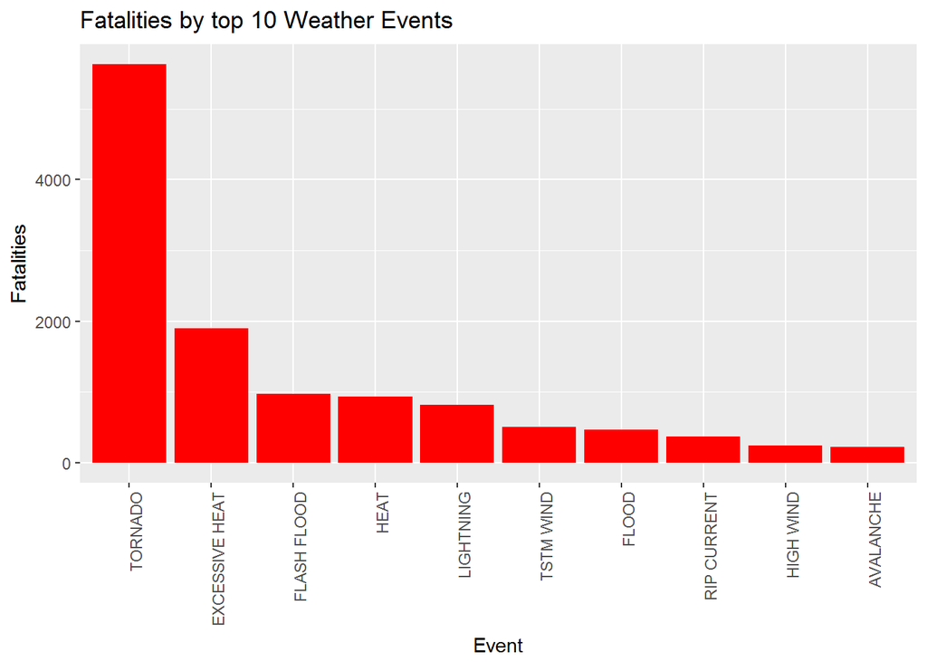

```r
library(ggplot2)
ggplot(fatalities, aes(x = EVTYPE, y = FATALITIES)) +
    geom_bar(stat = "identity", fill = "red") +
    theme(axis.text.x = element_text(angle = 90, hjust = 1)) +
    ggtitle("Fatalities by top 10 Weather Events") +
    xlab("Event") + ylab("Fatalities")
```

It is very clear from the plot that “Tornado” causes the most amount of fatalities.

**b) Injuries**

```r
injuries <- aggregate(INJURIES ~ EVTYPE, data=plotdata, sum)
injuries <- injuries[order(-injuries$INJURIES), ][1:10, ]
injuries$EVTYPE <- factor(injuries$EVTYPE, levels = injuries$EVTYPE)
injuries
```

```
##                EVTYPE INJURIES
## 366           TORNADO    91346
## 381         TSTM WIND     6957
## 76              FLOOD     6789
## 53     EXCESSIVE HEAT     6525
## 229         LIGHTNING     5230
## 130              HEAT     2100
## 212         ICE STORM     1975
## 64        FLASH FLOOD     1777
## 325 THUNDERSTORM WIND     1488
## 113              HAIL     1361
```

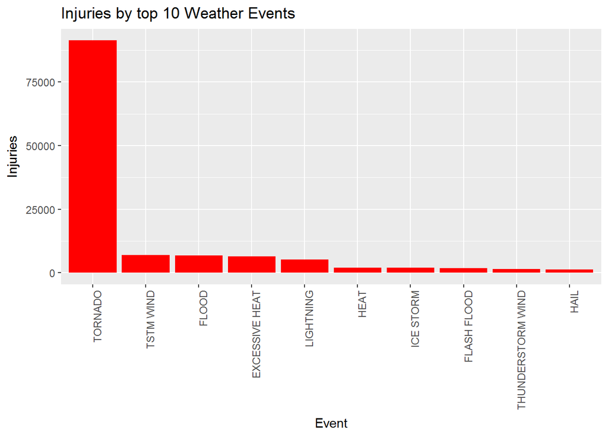

```r
ggplot(injuries, aes(x = EVTYPE, y = INJURIES)) +
    geom_bar(stat = "identity", fill = "red") +
    theme(axis.text.x = element_text(angle = 90, hjust = 1)) +
    ggtitle("Injuries by top 10 Weather Events") +
    xlab("Event") + ylab("Injuries")
```

It is very clear from the plot that “Tornado” causes the most amount of injures as well.

**Top 10 events across the United States that have the greatest economic consequences**

```r
damages <- aggregate(PropertyDamages+CropDamages ~ EVTYPE, data=plotdata, sum)
names(damages) <- c("EVTYPE","TotalDamages")
damages <- damages[order(-damages$TotalDamages), ][1:10, ]
damages$EVTYPE <- factor(damages$EVTYPE, levels = damages$EVTYPE)
damages
```

```
##                EVTYPE TotalDamages
## 76              FLOOD   150.319678
## 199 HURRICANE/TYPHOON    71.913713
## 366           TORNADO    57.340614
## 313       STORM SURGE    43.323541
## 113              HAIL    18.752904
## 64        FLASH FLOOD    17.562129
## 42            DROUGHT    15.018672
## 190         HURRICANE    14.610229
## 276       RIVER FLOOD    10.148404
## 212         ICE STORM     8.967041
```

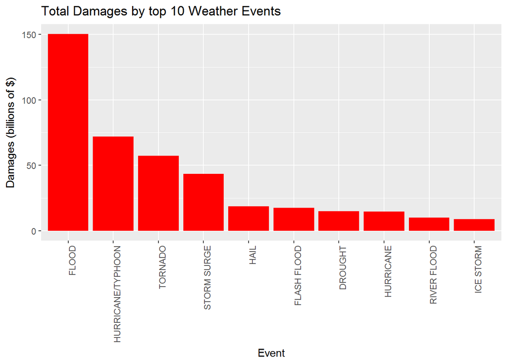

```r
ggplot(damages, aes(x = EVTYPE, y = TotalDamages)) +
    geom_bar(stat = "identity", fill = "red") +
    theme(axis.text.x = element_text(angle = 90, hjust = 1)) +
    ggtitle("Total Damages by top 10 Weather Events") +
    xlab("Event") + ylab("Damages (billions of $)")
```

It is very clear from the plot that “Flood” causes the most amount of economic consequences in the form of property and crop damages.